# INA_only

Chris Buddenhagen

25/02/2022

## Attempt notes

I set up a small adjacency matrix for the quick running of INAscene.

```r
data<-read_csv("Inputs/Simple_points_for_INA.csv")
adj<-readRDS("Inputs/farm2farm_probs.rds")
#dimnames(adj)<-NULL
class(data)
```

```
## [1] "spec_tbl_df" "tbl_df"      "tbl"         "data.frame"
```

```r
class(adj)
```

```
## [1] "matrix" "array"
```

```r
#make a small data set to test
waipawa<- data %>%
  filter(postal_twn=="Waipawa")
colnames(adj)
```

[output not shown]

[output cut: 247 more lines]

```r
#I wanted to us a matrix with named rows and columns for easy reference to farms
smadj<-adj [waipawa$farm_id,waipawa$farm_id]

#But then I wondered if the row and column names were not expected in the adjacency matrix that INA package expects - so I removed the names
 b<-length(dimnames(smadj)[[1]])
b<-seq(1:b)
row.names(smadj)<-b
colnames(smadj)<-b
dimnames(smadj)<-NULL
prob_est<-waipawa %>%
  select(Probability_Estab) #this is vector of probabilities for establishment


prob_est<-as.vector(prob_est$Probability_Estab)

prob_est<-1-(1-prob_est)*20/100
class(prob_est)
```

```
## [1] "numeric"
```

```r
geocoords<-waipawa %>% select(X,Y) #I thought I didn't need it because I was using an adj matrix of dispersal probabilities but it asked me for it

x<-geocoords$X[1:140]
y<-geocoords$Y[1:140]

geocoords<-matrix(c(x,y), byrow = F, ncol = 2)
initbio<- rep(0, length(waipawa$farm_id))
initbio[2]<-1 #infested farm in Waipawa
class(initbio)
```

```
## [1] "numeric"
```

```r
#big matrix version

# geocoords2<-matrix(c(data$X, data$Y), byrow=F, ncol=2)
# prob_est2<-as.vector(data$Probability_Estab)
# prob_est2<-1-(1-prob_est2)*20/100
# class(prob_est2)
# initbio2<- rep(0, length(data$farm_id))
# initbio2[2]<-1 #infested farm in Waipawa
# class(initbio2)
```

This shows the outputs for the different things I entered. The minimum number of variables is longer than you’d expect.

> INA::INAscene(nreals = 10, ntimesteps = 10, doplot = T, initbio.n = 1, readbpam = T, bpam= smadj) Error in if (maneffdir != “decrease_estab” & maneffdir != “increase_estab”) { : missing value where TRUE/FALSE needed

> INA::INAscene(nreals = 10, ntimesteps = 10, doplot = T, initbio.n = 1, readbpam = T, bpam= smadj, maneffdir = “decrease_estab”, maneffmean = 1/14, maneffsd = 0.2) Error in INA::INAscene(nreals = 10, ntimesteps = 10, doplot = T, initbio.n = 1, : argument “readgeocoords” is missing, with no default

> INA::INAscene(nreals = 10, ntimesteps = 10, doplot = T, initbio.n = 1, readbpam = T, bpam= smadj, maneffdir = “decrease_estab”, maneffmean = 1/14, maneffsd = 0.2, readgeocoords = T, geocoords = geocoords) Error in INA::INAscene(nreals = 10, ntimesteps = 10, doplot = T, initbio.n = 1, : argument “readinitinfo” is missing, with no default

> INA::INAscene(nreals = 10, ntimesteps = 10, doplot = T, initbio.n = 1, readbpam = T, bpam= smadj, maneffdir = “decrease_estab”, maneffmean = 1/14, maneffsd = 0.2, readgeocoords = T, geocoords = geocoords, readinitinfo = F, initinfo.norp = ‘prop’, initinfo.p = c(0.01, 0.05, 0.1, 0.2, 0.3, 0.4, 0.5, 0.6, 0.7, 0.8) ) Error in INA::INAscene(nreals = 10, ntimesteps = 10, doplot = T, initbio.n = 1, : argument “readinitbio” is missing, with no default

> INA::INAscene(nreals = 10, ntimesteps = 10, doplot = T, readbpam = T, bpam= smadj, maneffdir = “decrease_estab”, maneffmean = 1/14, maneffsd = 0.2, readgeocoords = F, geocoords = geocoords, readinitinfo = F, initinfo.norp = ‘prop’, initinfo.p = c(0.01, 0.05, 0.1, 0.2, 0.3, 0.4, 0.5, 0.6, 0.7, 0.8), readinitbio = TRUE,initbio=initbio, readseam = FALSE, seamdist = “random”, seamrandp = c(0, 0.01, 0.05, 0.1, 0.2), readprobadoptvec=F, readprobestabvec = T, probestabvec = prob_est, usethreshman = F , randgeo = F) Error in cbind(xvec, yvec) : object ‘xvec’ not found

> INA::INAscene(nreals = 10, ntimesteps = 10, doplot = T, readbpam = T, bpam= smadj, maneffdir = “decrease_estab”, maneffmean = 1/14, maneffsd = 0.2, readgeocoords = T, geocoords = geocoords, readinitinfo = F, initinfo.norp = ‘prop’, initinfo.p = c(0.01, 0.05, 0.1, 0.2, 0.3, 0.4, 0.5, 0.6, 0.7, 0.8), readinitbio = TRUE,initbio=initbio, readseam = FALSE, seamdist = “random”, seamrandp = c(0, 0.01, 0.05, 0.1, 0.2), readprobadoptvec=F, readprobestabvec = T, probestabvec = prob_est, usethreshman = F ) Quitting from lines 66-69 (INA_only.Rmd) Error in if (dist4 == “random”) { : missing value where TRUE/FALSE needed Calls: … eval -> -> multsame2 -> setup2 -> initvals

> INA::INAscene(nreals = 10, ntimesteps = 10, doplot = T, readbpam = T, bpam= smadj, maneffdir = “decrease_estab”, maneffmean = 1/14, maneffsd = 0.2, readgeocoords = T, geocoords = geocoords, readinitinfo = T, initinfo.norp = ‘prop’, initinfo.p = c(0.01,0.05,0.1,0.2,0.4, 0.6, 0.8), readinitbio = TRUE,initbio=initbio, readseam = FALSE, seamdist = “random”, seamrandp = c(0, 0.01, 0.05, 0.1, 0.2), readprobadoptvec=F, readprobestabvec = T, probestabvec = prob_est, usethreshman = F ) Error in vect1 %*% amat : non-conformable arguments Calls: … eval -> -> multsame2 -> ntsteps2 -> spreadstep

With 5 iterations and 5 timesteps and 1800 nodes

[1] “ending parameter combination 37” Error: cannot allocate vector of size 25.6 Mb

A possible issue is that I haven’t set up a social network except “random”. I think I would be happy to run a model without a social network. Is that possible?

```r
CNGv1 <-
  INAscene(
    nreals = 15,
    ntimesteps = 65,
    doplot = F,
    readgeocoords = T,
    geocoords = geocoords,
    numnodes = NA,
    xrange = NA,
    yrange = NA,
    randgeo = F,
    readinitinfo = T,
    initinfo = initbio,
    initinfo.norp = NA,
    initinfo.n = NA,
    initinfo.p = NA,
    initinfo.dist = NA,
    readinitbio = T,
    initbio = initbio,
    initbio.norp = NA,
    initbio.n = NA,
    initbio.p = NA,
    initbio.dist = NA,
    readseam = F,
    seam = NA,
    seamdist = 'random',
    seamrandp = c(0.001,0.01, 0.05, 0.1),
    seampla = NA,
    seamplb = NA,
    readbpam = T,
    bpam = smadj,
    bpamdist = F,
    bpamrandp = NA,
    bpampla = NA,
    bpamplb = NA,
    readprobadoptvec = F,
    probadoptvec = NA,
    probadoptmean = seq(from = 0, to = 1, by = 0.1),
    probadoptsd = 0.3,
    readprobestabvec = T,
    probestabvec = prob_est,
    probestabmean = NA,
    probestabsd = NA,
    maneffdir = 'decrease_estab',
    maneffmean = seq(from = 0, to = 1, by = 0.1),
    maneffsd = 0.2,
    usethreshman = F,
    maneffthresh = NA,
    sampeffort = 2
  )
```

```
## [1] "ending parameter combination 1"
## [1] "ending parameter combination 2"
## [1] "ending parameter combination 3"
## [1] "ending parameter combination 4"
## [1] "ending parameter combination 5"
## [1] "ending parameter combination 6"
## [1] "ending parameter combination 7"
## [1] "ending parameter combination 8"
## [1] "ending parameter combination 9"
## [1] "ending parameter combination 10"
## [1] "ending parameter combination 11"
## [1] "ending parameter combination 12"
## [1] "ending parameter combination 13"
## [1] "ending parameter combination 14"
## [1] "ending parameter combination 15"
```

[output cut: 469 more lines]

```r
saveRDS(CNGv1, "~/Sleeper Weeds/Waipawa_model.rds")
```

Plots

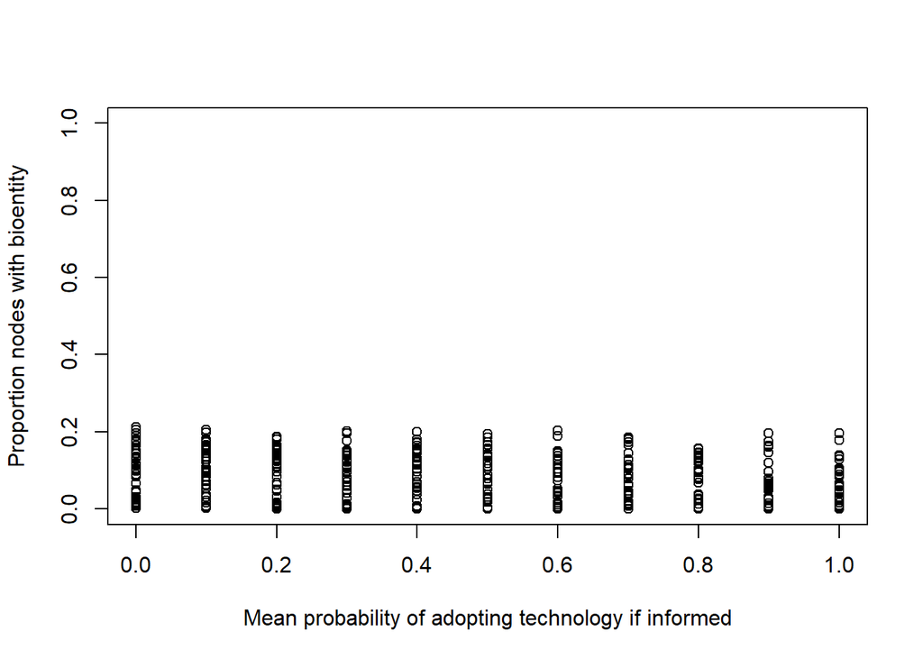

```r
jt <- CNGv1$multout

plot(jt$probadoptmean, jt$mestab, xlab='Mean probability of adopting technology if informed', ylab='Proportion nodes with bioentity', xlim=c(0,1), ylim=c(0,1))
```

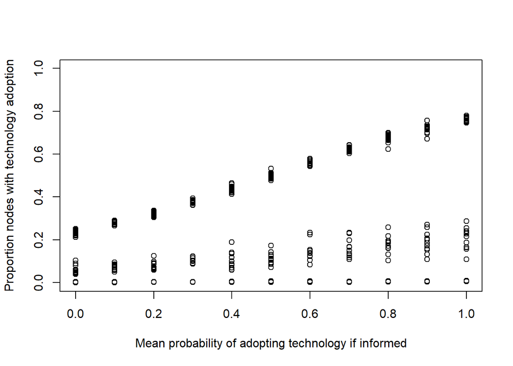

```r
plot(jt$probadoptmean, jt$mdec, xlab='Mean probability of adopting technology if informed', ylab='Proportion nodes with technology adoption', xlim=c(0,1), ylim=c(0,1))
```

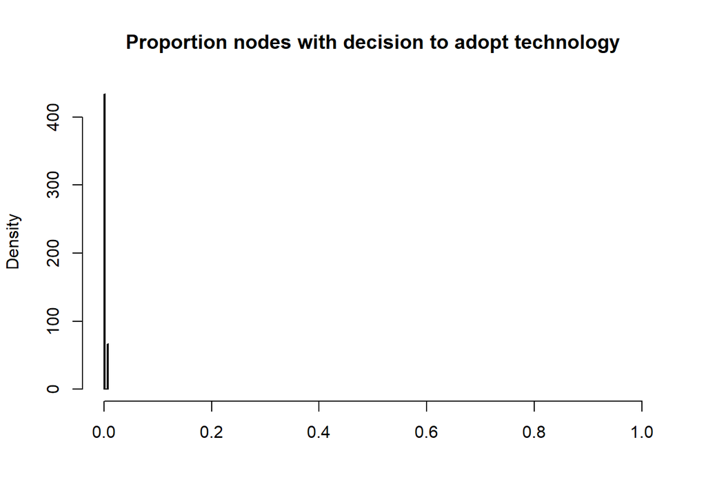

```r
jt2 <- CNGv1$multdetails
hist(
jt2[[1]]$setodec,
main = 'Proportion nodes with decision to adopt technology',
xlim = c(0, 1),
xlab = '',
col = 'darkblue',
freq = F
)
```

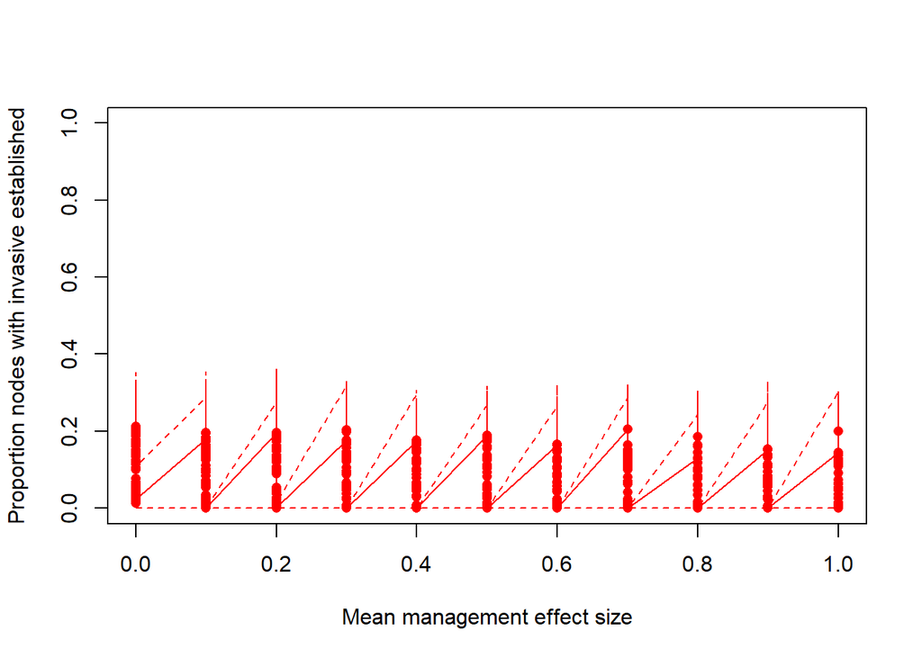

```r
jt2 <- CNGv1$multout
# Plot how the mean establishment proportion is a function of the mean
# management effect

plot(
jt2$maneffmean,
jt2$mestab,
xlab = 'Mean management effect size',
ylab = 'Proportion nodes with invasive established',
ylim = c(0, 1),
col = 'red',
pch = 16
)
lines(jt2$maneffmean, jt2$mestab, col = 'red')
# also indicate the 95th percentile
lines(jt2$maneffmean, jt2$estab95, col='red', lty=2)
# also indicate the 5th percentile
lines(jt2$maneffmean, jt2$estab5, col='red', lty=2)
```

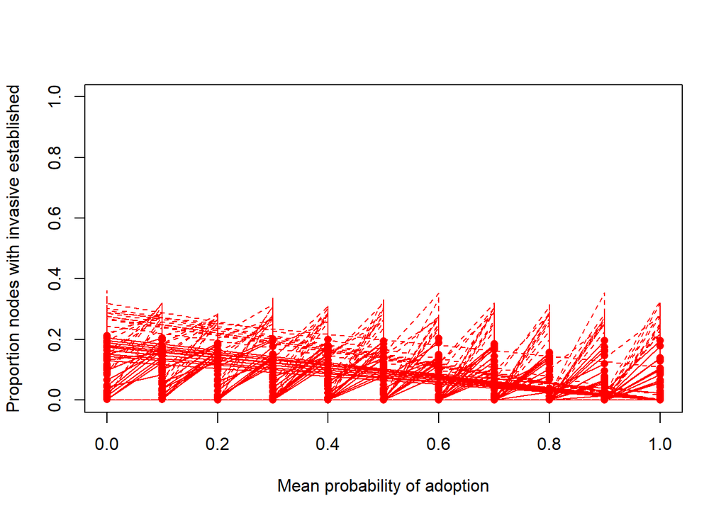

```r
plot(
jt2$probadoptmean,
jt2$mestab,
xlab = 'Mean probability of adoption',
ylab = 'Proportion nodes with invasive established',
ylim = c(0, 1),
col = 'red',
pch = 16
)
lines(jt2$probadoptmean, jt2$mestab, col='red')
# also indicate the 95th and 5th percentile
lines(jt2$probadoptmean, jt2$estab95, col='red', lty=2)
lines(jt2$probadoptmean, jt2$estab5, col='red', lty=2)
```

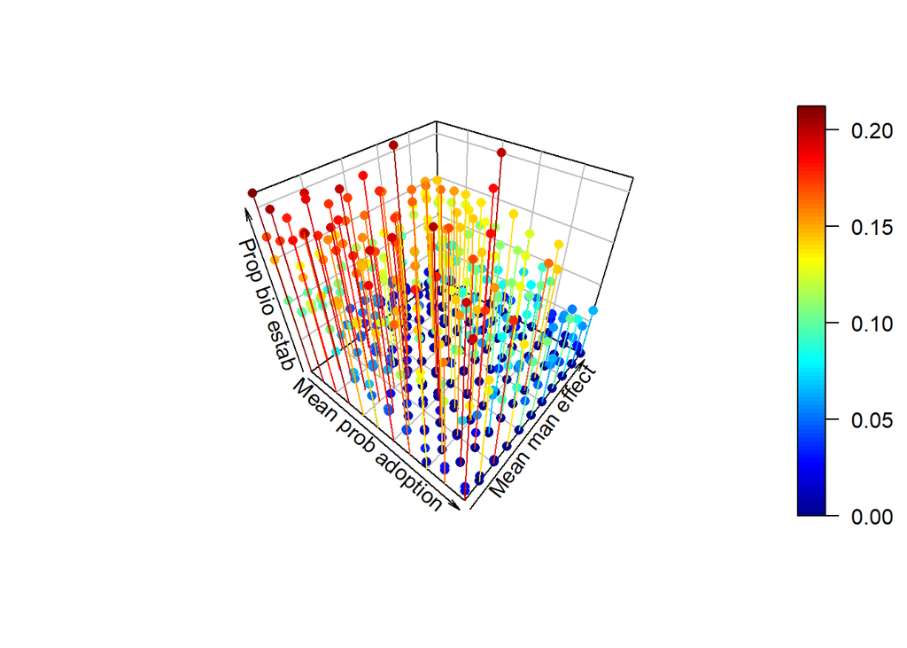

```r
library(plot3D)
plot3D::scatter3D(
x = jt2$probadoptmean,
y = jt2$maneffmean,
z = jt2$mestab,
pch = 16,
xlab = 'Mean prob adoption',
ylab = 'Mean man effect',
zlab = 'Prop bio estab',
bty = 'b2',
type = 'h'
)
```